# Tidy Data Intro

We will be exploring functions from the `tidyr` package to create tidy datasets. `tidyr` is part of the `tidyverse`.

```r
library(tidyverse)
```

## Tidy Data

We will explore how to convert data from a raw to a **tidy format**.

Goals:

- Reshape data using functions from the `tidyr` package, including `gather()`, `spread()`, `separate()`, and `unite()`.
- Combine information from different tables using `join()` functions from the `dplyr` package.
- Combine information from different tables using binding functions from the `dplyr` package.
- Use set operators to combine data frames.

In tidy data: - each row represents an observation

- each column represents a different variable.

In *wide* data:

- each row includes several observations
- one of the variables is stored in the header.

Check the `gapminder` dataset:

```r
library(dslabs)
data(gapminder)
```

Get a subset of the `gapminder` data with only information from South Korea and Germany:

```r
# create and inspect a tidy data frame
sk_german <- gapminder[c(which(gapminder$country=='South Korea'), which(gapminder$country=='Germany')), ]

tidy_data <- filter(gapminder, country %in% c("South Korea", "Germany")) %>% select(country, year, fertility)

# Check first rows
head(sk_german)
```

|  | country | year | infant_mortality | life_expectancy | fertility | population | gdp | continent | region |
| --- | --- | --- | --- | --- | --- | --- | --- | --- | --- |
| 90 | South Korea | 1960 | 80.2 | 53.02 | 6.16 | 25074028 | 28928298962 | Asia | Eastern Asia |
| 275 | South Korea | 1961 | 76.1 | 53.75 | 5.99 | 25808542 | 30356298714 | Asia | Eastern Asia |
| 460 | South Korea | 1962 | 72.4 | 54.51 | 5.79 | 26495107 | 31102566019 | Asia | Eastern Asia |
| 645 | South Korea | 1963 | 68.8 | 55.27 | 5.57 | 27143075 | 34067175844 | Asia | Eastern Asia |
| 830 | South Korea | 1964 | 65.3 | 56.04 | 5.36 | 27770874 | 36643076469 | Asia | Eastern Asia |
| 1015 | South Korea | 1965 | 61.6 | 56.84 | 5.16 | 28392722 | 38544903391 | Asia | Eastern Asia |

```r
NA
```

Simple plot using `ggplot()`:

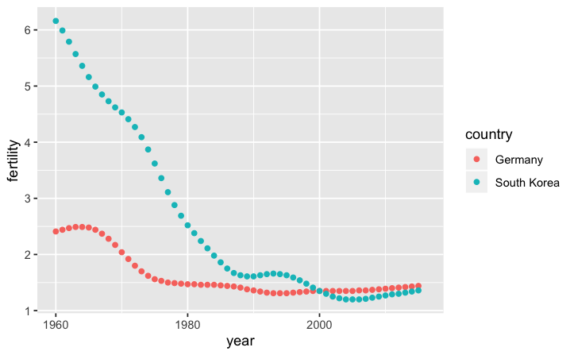

```r
# plotting tidy data is simple
tidy_data %>%
  ggplot(aes(year, fertility, color = country)) +
  geom_point()
```

Notice the data in wide format:

```r
# import and inspect example of original Gapminder data in wide format
path <- system.file("extdata", package="dslabs")
filename <- file.path(path,  "fertility-two-countries-example.csv")
wide_data <- read_csv(filename)
select(wide_data, country, `1960`:`1967`)
```

| country | 1960 | 1961 | 1962 | 1963 | 1964 | 1965 | 1966 | 1967 |
| --- | --- | --- | --- | --- | --- | --- | --- | --- |
| Germany | 2.41 | 2.44 | 2.47 | 2.49 | 2.49 | 2.48 | 2.44 | 2.37 |
| South Korea | 6.16 | 5.99 | 5.79 | 5.57 | 5.36 | 5.16 | 4.99 | 4.85 |

## Reshaping data

The `tidyr` package includes several functions that are useful for tidying data.

### `gather()`

- The `gather()` function converts wide data into tidy data.

The first argument sets the name of the column that will hold the variable that are currently kept in the wide data column names.

The second argument sets the column name for the column that will hold the values in the column cells. In this case, we’ll call it `fertility` since that’s the data that is in those cells.

```r
# gather wide data to make new tidy data
#converts wide to long
gather(wide_data, year, fertility, `1960`:`2015`)
```

| country | year | fertility |
| --- | --- | --- |
| Germany | 1960 | 2.41 |
| South Korea | 1960 | 6.16 |
| Germany | 1961 | 2.44 |
| South Korea | 1961 | 5.99 |
| Germany | 1962 | 2.47 |
| South Korea | 1962 | 5.79 |
| Germany | 1963 | 2.49 |
| South Korea | 1963 | 5.57 |
| Germany | 1964 | 2.49 |
| South Korea | 1964 | 5.36 |

[output cut: 102 more lines]

```r
NA
```

Equivalently:

```r
# gather all columns except country
new_tidy_data <- gather(wide_data, year, fertility, -country)
new_tidy_data
```

| country | year | fertility |
| --- | --- | --- |
| Germany | 1960 | 2.41 |
| South Korea | 1960 | 6.16 |
| Germany | 1961 | 2.44 |
| South Korea | 1961 | 5.99 |
| Germany | 1962 | 2.47 |
| South Korea | 1962 | 5.79 |
| Germany | 1963 | 2.49 |
| South Korea | 1963 | 5.57 |
| Germany | 1964 | 2.49 |
| South Korea | 1964 | 5.36 |

[output cut: 102 more lines]

```r
NA
NA
```

The object looks a lot like the original tidy data we showed earlier. There’s just one minor difference. (Look at the data type for the `Year` column. It’s an integer in our original tidy data table. In our new tidy data, the one we just *gathered*, it’s a character)

The `gather()` function assumes that column names are characters, so we need a bit more wrangling before we are ready to make a plot.

```r
# gather treats column names as characters by default
typeof(tidy_data$year)
```

```
[1] "integer"
```

```r
typeof(new_tidy_data$year)
```

```
[1] "character"
```

Fix:

```r
# convert gathered column names to numeric
new_tidy_data <- gather(wide_data, year, fertility, -country, convert=T)
typeof(new_tidy_data$year)
```

```
[1] "integer"
```

Quick plot:

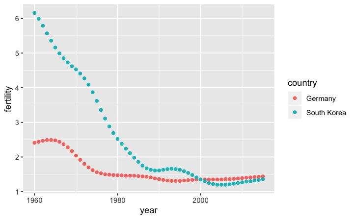

```r
# ggplot works on new tidy data
new_tidy_data %>%
  ggplot(aes(year, fertility, color = country)) +
  geom_point()
```

### `spread()`

- The `spread()` function converts tidy data to wide data.

It is sometimes useful for data wrangling purposes to convert tidy data into the wide format data. We often use this as an intermediate step in tidying up data. The `spread()` function is basically the *inverse* of `gather()`. The first argument tells `spread()` which variables will be used as the column names. The second argument specifies which variables to use to fill out the cells.

The following converts tidy data back into the *wide format*

```r
# spread tidy data to generate wide data
new_wide_data <- spread(new_tidy_data, year, fertility)
new_wide_data %>% select(country, `1960`:`1967`)
```

| country | 1960 | 1961 | 1962 | 1963 | 1964 | 1965 | 1966 | 1967 |
| --- | --- | --- | --- | --- | --- | --- | --- | --- |
| Germany | 2.41 | 2.44 | 2.47 | 2.49 | 2.49 | 2.48 | 2.44 | 2.37 |
| South Korea | 6.16 | 5.99 | 5.79 | 5.57 | 5.36 | 5.16 | 4.99 | 4.85 |

```r
NA
```

## Separate and Unite

Get some data for illustration:

```r
# import data
path <- system.file("extdata", package = "dslabs")
filename <- file.path(path, "life-expectancy-and-fertility-two-countries-example.csv")
raw_dat <- read_csv(filename)
select(raw_dat, 1:5)
```

| country | 1960_fertility | 1960_life_expectancy | 1961_fertility | 1961_life_expectancy |
| --- | --- | --- | --- | --- |
| Germany | 2.41 | 69.26 | 2.44 | 69.85 |
| South Korea | 6.16 | 53.02 | 5.99 | 53.75 |

When we look at this table, we can see that it is in wide format. Also note that there are values for two variables with the column names encoding which column represents which variable.

We can start the data wrangling with the `gather()` function, but we should no longer use the column name `Year` for the new columns, since it also contains the *variable type*. We will call it *key*.

```r
# gather all columns except country
dat <- raw_dat %>%  gather(key, value, -country)
dat
```

| country | key | value |
| --- | --- | --- |
| Germany | 1960_fertility | 2.41 |
| South Korea | 1960_fertility | 6.16 |
| Germany | 1960_life_expectancy | 69.26 |
| South Korea | 1960_life_expectancy | 53.02 |
| Germany | 1961_fertility | 2.44 |
| South Korea | 1961_fertility | 5.99 |
| Germany | 1961_life_expectancy | 69.85 |
| South Korea | 1961_life_expectancy | 53.75 |
| Germany | 1962_fertility | 2.47 |
| South Korea | 1962_fertility | 5.79 |

[output cut: 214 more lines]

```r
f_dat <- dat %>% separate(key, c("year", "variable_name1", "variable_name2"), sep="_")
```

```
Expected 3 pieces. Missing pieces filled with `NA` in 112 rows [1, 2, 5, 6, 9, 10, 13, 14, 17, 18, 21, 22, 25, 26, 29, 30, 33, 34, 37, 38, ...].
```

```r
f_dat
```

| country | year | variable_name1 | variable_name2 | value |
| --- | --- | --- | --- | --- |
| Germany | 1960 | fertility | NA | 2.41 |
| South Korea | 1960 | fertility | NA | 6.16 |
| Germany | 1960 | life | expectancy | 69.26 |
| South Korea | 1960 | life | expectancy | 53.02 |
| Germany | 1961 | fertility | NA | 2.44 |
| South Korea | 1961 | fertility | NA | 5.99 |
| Germany | 1961 | life | expectancy | 69.85 |
| South Korea | 1961 | life | expectancy | 53.75 |
| Germany | 1962 | fertility | NA | 2.47 |
| South Korea | 1962 | fertility | NA | 5.79 |

[output cut: 214 more lines]

```r
s_dat = dat %>% separate(key, c("year", "variable"), extra="merge")
s_dat
```

| country | year | variable | value |
| --- | --- | --- | --- |
| Germany | 1960 | fertility | 2.41 |
| South Korea | 1960 | fertility | 6.16 |
| Germany | 1960 | life_expectancy | 69.26 |
| South Korea | 1960 | life_expectancy | 53.02 |
| Germany | 1961 | fertility | 2.44 |
| South Korea | 1961 | fertility | 5.99 |
| Germany | 1961 | life_expectancy | 69.85 |
| South Korea | 1961 | life_expectancy | 53.75 |
| Germany | 1962 | fertility | 2.47 |
| South Korea | 1962 | fertility | 5.79 |

[output cut: 214 more lines]

And the result is not exactly what we refer to as *tidy*: each observation is associated with two, not one, rows. We want to have the value from the two variables, `fertility` and `life_expectancy`, as two separate columns. The first challenge to achieve this is to *separate* the key column into the year and the variable type.

Note that the entries in this column separate the year from the variable name using an underscore.

- The `separate()` function splits one column into two or more columns at a specified character that separates the variables.

Arguments:

- the name of the column to be separated,
- the names to be used for the new columns, and
- the character that separates the variables.

```r
# separate on underscores
```

```r
# split on all underscores, pad empty cells with NA
```

A better approach is to *merge* the last two variables when there is an extra separation using the argument `extra`:

```r
# split on first underscore but keep life_expectancy merged
```

We need to create a column for each variable. As we’ve learned, the `spread()` function can do this. (in this case, to create tidy data, we are actually using the spread function!).

```r
# separate then spread
out_put <- s_dat %>% spread(variable, value)
out_put
```

| country | year | fertility | life_expectancy |
| --- | --- | --- | --- |
| Germany | 1960 | 2.41 | 69.26 |
| Germany | 1961 | 2.44 | 69.85 |
| Germany | 1962 | 2.47 | 70.01 |
| Germany | 1963 | 2.49 | 70.10 |
| Germany | 1964 | 2.49 | 70.66 |
| Germany | 1965 | 2.48 | 70.65 |
| Germany | 1966 | 2.44 | 70.77 |
| Germany | 1967 | 2.37 | 70.99 |
| Germany | 1968 | 2.28 | 70.64 |
| Germany | 1969 | 2.17 | 70.48 |

[output cut: 102 more lines]

```r
NA
NA
```

- When there is an extra separation in some of the entries, use `fill="right"` to pad missing values with `NA`s, or use `extra="merge"` to keep extra elements together.
- The `unite()` function combines two columns and adds a separating character.

In this case we could also use `unite()` after the `separate()` to build the tidy data set:

```r
# full code for tidying data
dat %>%  separate(key, c("year", "var1", "var2")) %>% unite(variable_name, var1, var2) %>% spread(variable_name, value) %>% rename(fertility=fertility_NA)
```

```
Expected 3 pieces. Missing pieces filled with `NA` in 112 rows [1, 2, 5, 6, 9, 10, 13, 14, 17, 18, 21, 22, 25, 26, 29, 30, 33, 34, 37, 38, ...].
```

| country | year | fertility | life_expectancy |
| --- | --- | --- | --- |
| Germany | 1960 | 2.41 | 69.26 |
| Germany | 1961 | 2.44 | 69.85 |
| Germany | 1962 | 2.47 | 70.01 |
| Germany | 1963 | 2.49 | 70.10 |
| Germany | 1964 | 2.49 | 70.66 |
| Germany | 1965 | 2.48 | 70.65 |
| Germany | 1966 | 2.44 | 70.77 |
| Germany | 1967 | 2.37 | 70.99 |
| Germany | 1968 | 2.28 | 70.64 |
| Germany | 1969 | 2.17 | 70.48 |

[output cut: 102 more lines]

```r
NA
NA
```

## Pivoting

### Longer

A common problem is a dataset where some of the column names are not names of variables, but values of a variable. Take `table4a`: the column names `1999` and `2000` represent values of the `year` variable, the values in the `1999` and `2000` columns represent values of the `cases` variable, and each row represents two observations, not one!

```r
# print table4a
```

[output not shown]

To *tidy* a dataset like this, we need to **pivot** the offending columns into a new pair of variables. To describe that operation we need three parameters:

1. The set of columns whose names are values, not variables. In this example, those are the columns `1999` and `2000`.
2. The name of the variable to move the column names to. Here it is `year`.
3. The name of the variable to move the column values to. Here it is `cases`.

### Wider

`pivot_wider()` is the opposite of `pivot_longer()`. You use it when an observation is *scattered across multiple rows*. For example, take `table2`: an observation is a country in a year, but each observation is spread across two rows.

To *tidy* this up, we first analyse the representation in similar way to `pivot_longer()`. This time, however, we only need two parameters:

1. The column to take variable names from. Here, it is `type`.
2. The column to take values from. Here it is `count`.

`pivot_longer()` makes wide tables narrower and longer; `pivot_wider()` makes long tables shorter and wider.